# Corrected multi-trait omnibus association test on body-related traits in UKBiobank

Andrey Ziyatdinov

2018-05-21

# 1 About

Updated on [Report 2: Single- and multi-trait association analysis on body-related traits in UKBiobank](https://hemostat.github.io/Public/ukbjass/reports/02-body-traits/02-body-traits.html).

See also Figure S6. Impact of covariance bias on multivariate tests.

# 2 Phenotypic correlations

Plots:

- phenotypic correlations estimated on raw data of phenotypes;
- phenotypic correlations ($\rho = \rho_g + \rho_e$) estimated on summary stats by LDSC;
  - off-diagonal entries from bi-variate LDSC;
  - diagonal entries from uni-variate LDSC;
- absolute (signed) errors;
- relative (signed) errors.

Height is excluded from the multi-trait analysis.

## 2.1 Correlation matrix from LDSC

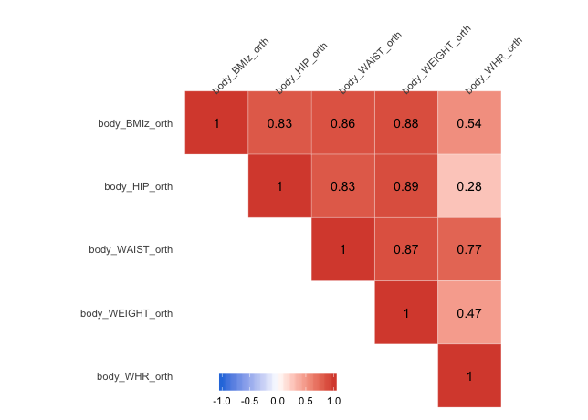

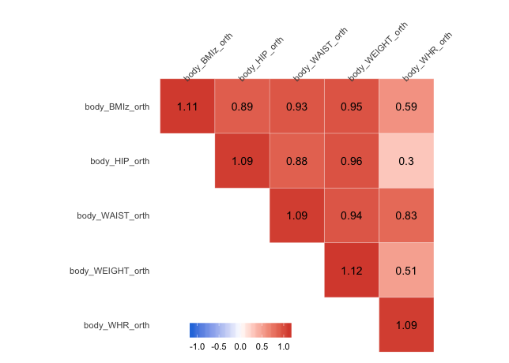

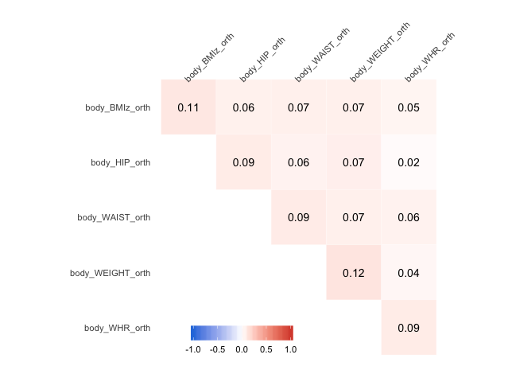

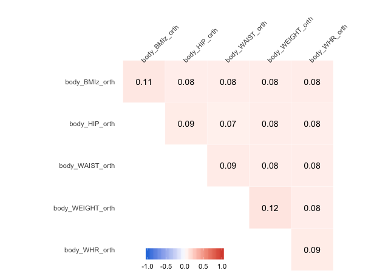

## 2.2 (Scaled) Correlation matrix from LDSC

We applied the `cov2cor` function for scaling.

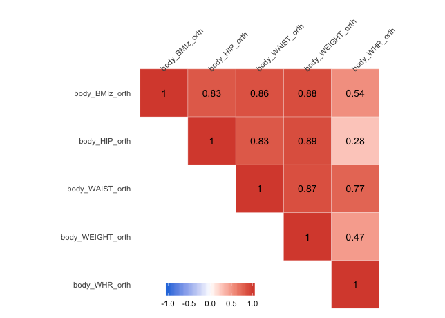

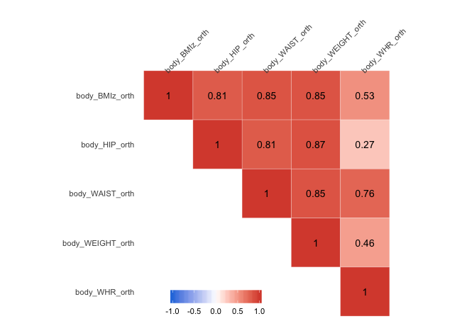

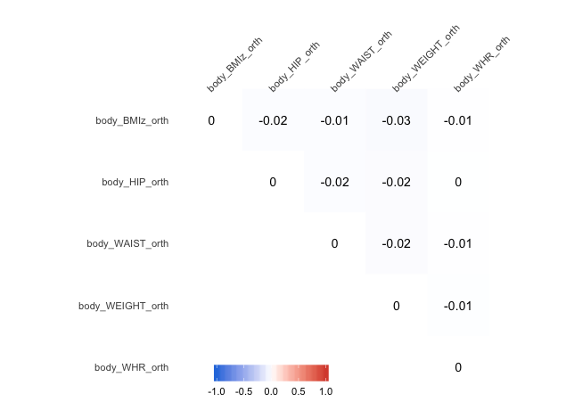

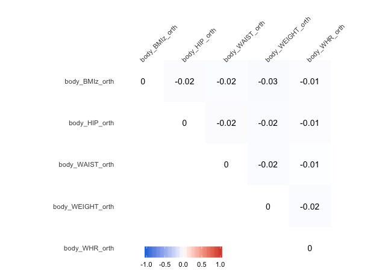

# 3 Multi-trait association tests (Chr. 20)

We compared p-values obtained from the following tests.

- `P_phen`: the Omnibus test with the covariance matrix estimated from the raw phenotype data (the correlation matrix among phenotypes);
- `P_ldsc`: the Omnibus test with the covariance matrix by LDSC;
- `P_ldsc_sc`: the Omnibus test with the covariance matrix by LDSC and further scale by `cov2cor` function;

Note that `P_phen` seem to be in a good concordance with MANOVA (see the next section), which in turn well approximates the PLINK-CCA test.

Analysis is performed on SNPs from Chr. 20.

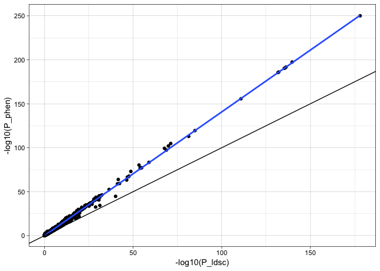

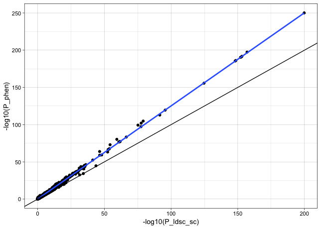

## 3.1 Zoom-in

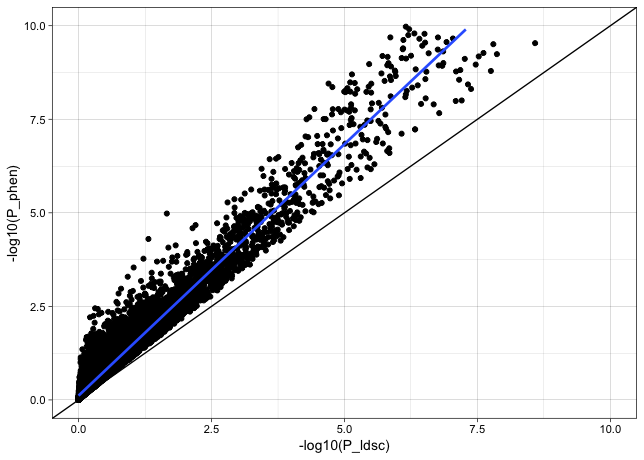

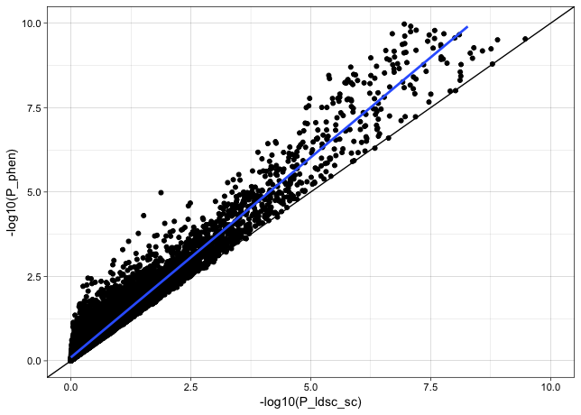

## 3.2 Comparison between MANOVA (approx. PLINK-CCA) and JASS Ominbus (phen. cor.)

We pick 10 random SNPs in Chr. 20 and run MANOVA using raw data.

```
Reading /Users/andreyziyatdinov/Data/UKBiobank/jass/clean.maf_0.01/20.clean.fam
Reading /Users/andreyziyatdinov/Data/UKBiobank/jass/clean.maf_0.01/20.clean.bim
Reading /Users/andreyziyatdinov/Data/UKBiobank/jass/clean.maf_0.01/20.clean.bed
```

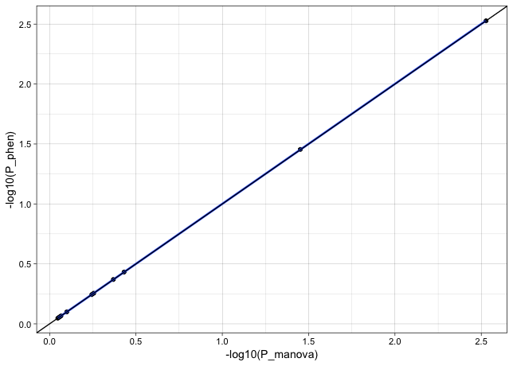